# BA1 geophysical/chemical logs

Source file: 201012_BA1_Logs.Rmd

Daniel Nothaft

16 Dec 2021

# 1 Setup

## 1.1 Load code libraries

```r
# load libraries
library(tidyverse) # dplyr, tidyr, ggplot
library(readxl) # reading excel files
library(knitr) # generating reports
library(ggpmisc) # add equations of best fit to ggplot
library(scales) # making log scales with exponents
library(lemon) # repeat axis lines for paneled figures in ggplot

# global knitting options for automatic saving of all plots as .png and .pdf
knitr::opts_chunk$set(
  dev = c("png", "pdf"), fig.keep = "all",
  dev.args = list(pdf = list(encoding = "WinAnsi", useDingbats = FALSE)),
  fig.path = file.path("fig_output/", paste0(gsub("\\.[Rr]md", "/", knitr::current_input()))),
  cache.path = file.path("cache/", paste0(gsub("\\.[Rr]md", "/", knitr::current_input())))
)
```

```r
# source all relevant scripting files
source(file.path("scripts", "plotting_functions.R"))
```

## 1.2 Load data

```r
# read BA1A borehole log from March 16th, 2018
BA1A_2018_profile_raw <- read_xlsx("data_raw/Summary_metadata/BA1A_QL40IDRO_20180316_DOWN_5cm.xlsx", na = c("-99999.00", "-99999"))

# # read BA1A borehole log from April 22nd, 2017
# BA1A_2017_profile_raw <- read_xlsx("data_raw/Summary_metadata/BA1A_Muset_22APRIL2017_run2_pass1_dw_5cm.xlsx", na = c("-99999.00", "-99999"))

# # read BA1A borehole log from March 19th, 2018
# BA1D_2018_profile_raw <- read_xlsx("data_raw/Summary_metadata/BA1D_QL40IDRO_20180319_down_5cm.xlsx", na = c("-99999.00", "-99999"))

# read BA1A borehole log from March 19th, 2018
BA1D_2019_profile_raw <- read_xlsx("data_raw/Summary_metadata/BA1D_2019_chemical_log.xlsx", na = c("-99999.00", "-99999"))

# For context, well BA1A was drilled in 2017, from February 20 to March 2, and BA1D was drilled in 2018, from February 24 to March 15.

# read Oman Geochem data, including data from packer sampling
Oman_Geochem <- read_xlsx("data_raw/Summary_metadata/Oman_Geochem_2012-2019_packers.xlsx", na = c("NA"))

# Read in conversion from Ag/AgCl electrode to SHE as function of T
Ag_AgCl_E_T <- read_xlsx("data_raw/Summary_metadata/Ag_AgCl_E_T.xlsx", na = "NA")
```

# 2 BA1A 2018 well log

## 2.1 clean up data

```r
# select relevant columns and rename them
BA1A_2018_profile <- BA1A_2018_profile_raw %>% select(depth_sampled_mbgl = depth_m, P_dbar = pressure, T_C = Temp_C, pH, ORP_mV_Ag_AgCl = ORP, cond_uS_per_cm = Cond_FW)

# Filter out nonsense values (i.e. when probe is above water table)
BA1A_2018_profile <- BA1A_2018_profile %>% filter_all(all_vars(!is.na(.)))

# convert conductivity to mS/cm
BA1A_2018_profile <- BA1A_2018_profile %>% mutate(cond_mS_per_cm = cond_uS_per_cm * 1e-3) %>% select(-cond_uS_per_cm)

# print some summary statistics
BA1A_2018_profile %>% summary()
```

```
##  depth_sampled_mbgl     P_dbar             T_C              pH
##  Min.   :  9.096    Min.   :  2.747   Min.   :33.33   Min.   : 4.872
##  1st Qu.:106.633    1st Qu.: 92.252   1st Qu.:35.50   1st Qu.: 7.929
##  Median :204.171    Median :187.144   Median :38.34   Median : 9.758
##  Mean   :204.171    Mean   :186.355   Mean   :38.30   Mean   : 9.138
##  3rd Qu.:301.708    3rd Qu.:280.844   3rd Qu.:40.85   3rd Qu.: 9.959
##  Max.   :399.246    Max.   :373.074   Max.   :43.32   Max.   :10.152
##  ORP_mV_Ag_AgCl   cond_mS_per_cm
##  Min.   :-777.3   Min.   :0.003841
##  1st Qu.:-765.0   1st Qu.:0.550330
##  Median :-554.1   Median :0.573157
##  Mean   :-353.7   Mean   :0.819267
##  3rd Qu.:  75.6   3rd Qu.:1.136210
##  Max.   : 244.1   Max.   :1.544091
```

```r
BA1A_2018_profile %>% head()
```

| depth_sampled_mbgl | P_dbar | T_C | pH | ORP_mV_Ag_AgCl | cond_mS_per_cm |
| --- | --- | --- | --- | --- | --- |
| 9.095901 | 2.938823 | 33.50554 | 6.799098 | 196.3673 | 0.004182398 |
| 9.145900 | 2.946671 | 33.49601 | 6.805885 | 196.3788 | 0.004395324 |
| 9.195900 | 2.871685 | 33.48883 | 6.815248 | 196.2838 | 0.004498888 |
| 9.245900 | 2.875826 | 33.48239 | 6.820409 | 196.0129 | 0.004779105 |
| 9.295900 | 2.897442 | 33.47717 | 6.829166 | 195.6746 | 0.004637673 |
| 9.345901 | 2.906633 | 33.46837 | 6.830161 | 195.5658 | 0.004807119 |

```r
# subset the data for readability and print
BA1A_2018_profile %>% slice(seq(from = 1, to = 10000, by = 200)) %>% kable(digits=1)
```

| depth_sampled_mbgl | P_dbar | T_C | pH | ORP_mV_Ag_AgCl | cond_mS_per_cm |
| --- | --- | --- | --- | --- | --- |
| 9.1 | 2.9 | 33.5 | 6.8 | 196.4 | 0.0 |
| 19.1 | 5.7 | 34.1 | 8.6 | 44.9 | 0.6 |
| 29.1 | 15.7 | 34.3 | 7.8 | 62.2 | 0.5 |
| 39.1 | 25.6 | 34.3 | 7.8 | 74.4 | 0.6 |
| 49.1 | 35.4 | 34.4 | 7.8 | 79.0 | 0.6 |
| 59.1 | 45.4 | 34.4 | 7.8 | 80.9 | 0.6 |
| 69.1 | 55.2 | 34.5 | 7.8 | 84.3 | 0.6 |
| 79.1 | 65.1 | 34.8 | 7.8 | 84.4 | 0.6 |
| 89.1 | 75.0 | 35.1 | 7.9 | 80.5 | 0.6 |
| 99.1 | 84.8 | 35.3 | 7.9 | 77.8 | 0.6 |
| 109.1 | 94.6 | 35.6 | 7.9 | 84.2 | 0.6 |
| 119.1 | 104.5 | 35.8 | 7.9 | 81.8 | 0.6 |
| 129.1 | 114.3 | 36.1 | 7.9 | 78.9 | 0.6 |
| 139.1 | 124.0 | 36.6 | 8.1 | 76.4 | 0.5 |
| 149.1 | 133.8 | 36.9 | 8.5 | 58.5 | 0.5 |
| 159.1 | 143.5 | 37.1 | 8.9 | 42.9 | 0.5 |
| 169.1 | 153.3 | 37.4 | 9.1 | 27.7 | 0.4 |
| 179.1 | 163.0 | 37.7 | 9.5 | 8.8 | 0.5 |
| 189.1 | 172.6 | 37.9 | 9.7 | -27.8 | 0.5 |
| 199.1 | 182.3 | 38.2 | 9.9 | -405.1 | 0.5 |
| 209.1 | 191.9 | 38.5 | 10.0 | -606.0 | 0.6 |
| 219.1 | 201.7 | 38.7 | 10.1 | -667.8 | 0.7 |
| 229.1 | 211.1 | 39.0 | 10.1 | -705.8 | 0.8 |
| 239.1 | 220.8 | 39.3 | 10.1 | -733.1 | 0.8 |
| 249.1 | 230.5 | 39.5 | 10.1 | -748.0 | 0.9 |
| 259.1 | 240.1 | 39.8 | 10.1 | -757.3 | 0.9 |
| 269.1 | 249.6 | 40.0 | 10.1 | -766.6 | 1.0 |
| 279.1 | 259.2 | 40.3 | 10.1 | -767.9 | 1.0 |
| 289.1 | 268.7 | 40.5 | 10.0 | -765.7 | 1.1 |
| 299.1 | 278.3 | 40.8 | 10.0 | -764.9 | 1.1 |
| 309.1 | 287.9 | 41.0 | 9.9 | -764.8 | 1.2 |
| 319.1 | 297.4 | 41.3 | 9.9 | -764.0 | 1.2 |
| 329.1 | 306.9 | 41.5 | 9.9 | -764.5 | 1.3 |
| 339.1 | 316.3 | 41.8 | 9.9 | -767.3 | 1.3 |
| 349.1 | 325.8 | 42.1 | 9.9 | -770.0 | 1.4 |
| 359.1 | 335.2 | 42.3 | 9.8 | -770.6 | 1.4 |
| 369.1 | 344.8 | 42.6 | 9.8 | -770.2 | 1.5 |
| 379.1 | 354.1 | 42.8 | 9.8 | -773.1 | 1.5 |
| 389.1 | 363.6 | 43.1 | 9.8 | -775.0 | 1.5 |
| 399.1 | 372.9 | 43.3 | 9.7 | -772.1 | 1.5 |

## 2.2 Convert to ORP to SHE

Plot conversion between Ag/AgCl electrode and SHE as function of temperature

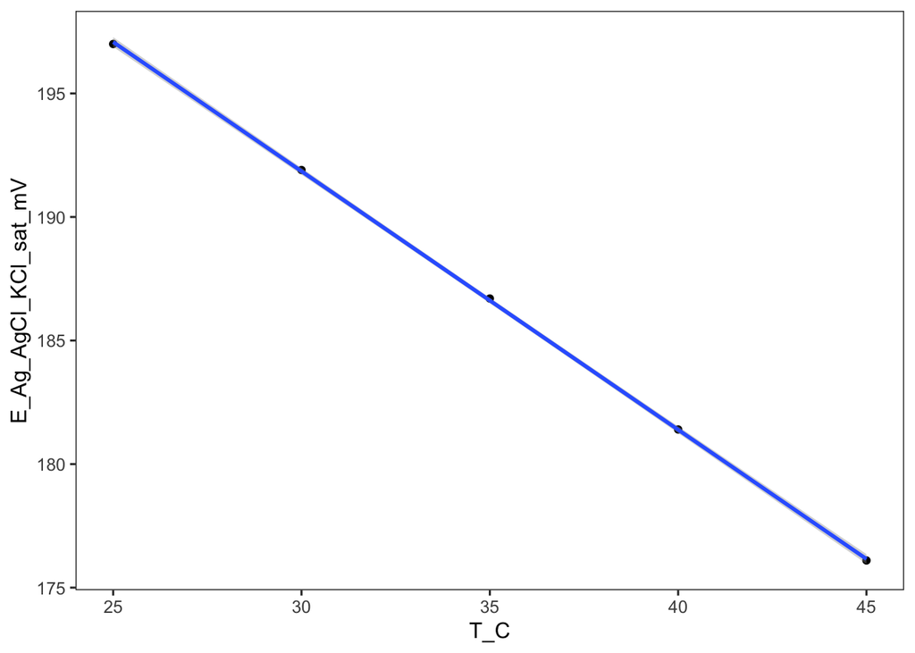

```r
formula <- Ag_AgCl_E_T$E_Ag_AgCl_KCl_sat_mV ~ Ag_AgCl_E_T$T_C

plot_redox_offset_T <- Ag_AgCl_E_T %>% ggplot(aes(x = T_C, y = E_Ag_AgCl_KCl_sat_mV))+
  geom_point()+
  geom_smooth(method="lm")+
  stat_poly_eq(aes(label =  paste(stat(eq.label), stat(rr.label), sep = "~~~~")),
               formula = formula, parse = TRUE, rr.digits = 2, label.x = .2, label.y = .9)+
  theme_bw(base_size = 12)+
  theme(
    panel.grid = element_blank())

plot_redox_offset_T
```

Save a linear model of the relationship between Ag/AgCl electrode and SHE as function of temperature

```r
Ag_AgCl_E_T_lm <- lm(formula)

Ag_AgCl_E_T_lm_summ <- Ag_AgCl_E_T_lm %>% summary()

Ag_AgCl_E_T_lm_summ
```

```
##
## Call:
## lm(formula = formula)
##
## Residuals:
##     1     2     3     4     5
## -0.08  0.05  0.08  0.01 -0.06
##
## Coefficients:
##                   Estimate Std. Error t value Pr(>|t|)
## (Intercept)     223.230000   0.179722  1242.1 1.15e-09 ***
## Ag_AgCl_E_T$T_C  -1.046000   0.005033  -207.8 2.46e-07 ***
## ---
## Signif. codes:  0 '***' 0.001 '**' 0.01 '*' 0.05 '.' 0.1 ' ' 1
##
## Residual standard error: 0.07958 on 3 degrees of freedom
## Multiple R-squared:  0.9999, Adjusted R-squared:  0.9999
## F-statistic: 4.319e+04 on 1 and 3 DF,  p-value: 2.457e-07
```

Save slope

```r
Ag_AgCl_E_T_lm_slope <- coef(Ag_AgCl_E_T_lm_summ)["Ag_AgCl_E_T$T_C",  "Estimate"]

Ag_AgCl_E_T_lm_slope
```

```
## [1] -1.046
```

Save intercept

```r
Ag_AgCl_E_T_lm_int <- coef(Ag_AgCl_E_T_lm_summ)["(Intercept)",  "Estimate"]

Ag_AgCl_E_T_lm_int
```

```
## [1] 223.23
```

Apply conversion

```r
BA1A_2018_profile <- BA1A_2018_profile %>% mutate(Eh_mV = ORP_mV_Ag_AgCl + Ag_AgCl_E_T_lm_int + Ag_AgCl_E_T_lm_slope * T_C) # convert probe ORP_mV_Ag_AgCl reading from Ag/AgCl to SHE

# print some summary statistics
BA1A_2018_profile %>% select(Eh_mV) %>% summary()
```

```
##      Eh_mV
##  Min.   :-599.0
##  1st Qu.:-584.6
##  Median :-370.9
##  Mean   :-170.5
##  3rd Qu.: 262.1
##  Max.   : 432.4
```

## 2.3 Hydrostatic pressure

Pressure will be used to assess calculated stability limit of water with respect to molecular hydrogen.

Calculate from theory

```r
P_BA1A_2018_atmospheric_Pa <- 95490 # measured ambient pressure with Garmin GPSMAP 64S by DBN in 2019
P_BA1A_2018_atmospheric_bar <-  P_BA1A_2018_atmospheric_Pa * 1e-5

water_level_BA1A_2018_m <- as.numeric(BA1A_2018_profile %>% select(depth_sampled_mbgl) %>% min())

BA1A_2018_profile <- BA1A_2018_profile %>% mutate(water_column_above_m = depth_sampled_mbgl - water_level_BA1A_2018_m)


# Hydrostatic pressure in a liquid can be calculated as
#
# p = ρ g h                         (1)
#
# where
#
# p = pressure in liquid (N/m2, Pa, lbf/ft2, psf)
#
# ρ = density of liquid (kg/m3, slugs/ft3)
#
# g = acceleration of gravity (9.81 m/s2, 32.17405 ft/s2)
#
# h = height of fluid column - or depth in the fluid where pressure is measured (m, ft)

# https://www.engineeringtoolbox.com/hydrostatic-pressure-water-d_1632.html

density_water <- 1000 # kg/m3
g = 9.81 # acceleration of gravity, m/s2


BA1A_2018_profile <- BA1A_2018_profile %>% mutate(P_hydrostatic_calc_Pa = P_BA1A_2018_atmospheric_Pa + density_water * g * water_column_above_m)

BA1A_2018_profile <- BA1A_2018_profile %>% mutate(P_hydrostatic_calc_bar = P_hydrostatic_calc_Pa * 1e-5)

# print some summary statistics
BA1A_2018_profile %>% select(P_hydrostatic_calc_bar) %>% summary()
```

```
##  P_hydrostatic_calc_bar
##  Min.   : 0.9549
##  1st Qu.:10.5233
##  Median :20.0918
##  Mean   :20.0918
##  3rd Qu.:29.6602
##  Max.   :39.2286
```

```r
# convert measured pressure to bar
BA1A_2018_profile <- BA1A_2018_profile %>% mutate(P_bar = P_dbar / 10)
```

```r
# prepare for plotting
BA1A_2018_profile_longer_P <- BA1A_2018_profile %>% select(depth_sampled_mbgl, P_hydrostatic_calc_bar, P_bar) %>% gather(-depth_sampled_mbgl, key = parameter, value = P_bar) %>% mutate(type = if_else(parameter == "P_hydrostatic_calc_bar", "calculated", "measured"))
```

Compare theoretical hydrostatic pressure versus measured pressure

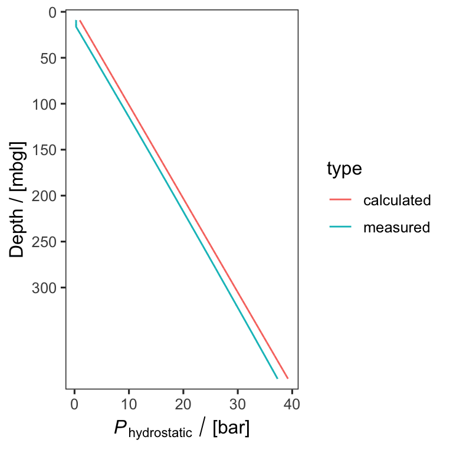

```r
plot_BA1A_2018_P <- BA1A_2018_profile_longer_P %>% ggplot(aes(x = depth_sampled_mbgl))+
  geom_line(aes(y = P_bar, color = type))+
  scale_x_reverse(name = "Depth / [mbgl]", expand = c(0.03,0.02), breaks = c(0, 50, 100, 150, 200, 250, 300))+
    scale_y_continuous(name = latex2exp::TeX("$\\textit{P}_{hydrostatic}\\,/\\,\\lbrack bar \\rbrack$"))+
  coord_flip()+
  theme_bw(base_size = 12)+
  theme(
    panel.grid = element_blank())

plot_BA1A_2018_P
```

They are similar.

## 2.4 Stability limits of water

Eh, f(T,P)

```r
Faraday <- 96485.33212331 # C/mol
R <- 8.31446261815324 # J/(mol⋅K) gas constant

BA1A_2018_profile <- BA1A_2018_profile %>% mutate(T_K= T_C + 273.15) # convert T to Kelvins

# calculate H20-H2 stability limit
BA1A_2018_profile <- BA1A_2018_profile %>% mutate(H2O_H2_limit_Eh_f_T_P_mV = (-R*T_K/2/Faraday * log(((10^-pH)^-2)*P_bar))*1000)

BA1A_2018_profile %>% select(H2O_H2_limit_Eh_f_T_P_mV) %>% summary()
```

```
##  H2O_H2_limit_Eh_f_T_P_mV
##  Min.   :-672.4
##  1st Qu.:-664.7
##  Median :-653.0
##  Mean   :-600.2
##  3rd Qu.:-514.7
##  Max.   :-279.9
```

```r
# prepare for plotting
BA1A_2018_profile_longer_Eh_T_P <- BA1A_2018_profile %>% select(depth_sampled_mbgl, Eh_mV, H2O_H2_limit_Eh_f_T_P_mV) %>% gather(-depth_sampled_mbgl, key = parameter, value = Eh_mV)
```

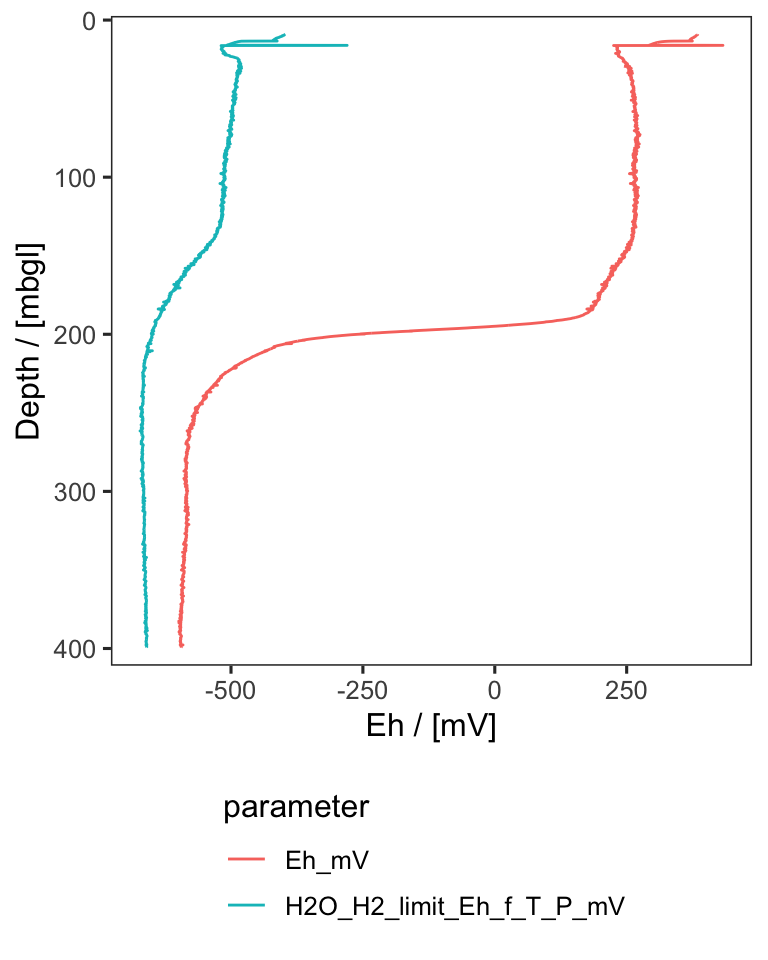

```r
plot_BA1A_2018_Eh <- BA1A_2018_profile_longer_Eh_T_P %>% ggplot(aes(x = depth_sampled_mbgl))+
  geom_line(aes(y = Eh_mV, color = parameter))+
  scale_x_reverse(name = "Depth / [mbgl]", expand = c(0.03,0.02))+
  scale_y_continuous(name = "Eh / [mV]")+
  coord_flip()+
  theme_bw(base_size = 12)+
  theme(
    panel.grid = element_blank(),
    legend.position = "bottom",
    legend.direction = "vertical")

plot_BA1A_2018_Eh
```

# 3 BA1A 2017 well log

## 3.1 clean up data

```r
# # select relevant columns and rename them
# BA1A_2017_profile <- BA1A_2017_profile_raw %>% select(depth_sampled_mbgl = `DEPT[M]`, P_dbar = PRESSURE, T_C = TEMP, pH = PH, ORP_mV_Ag_AgCl = EH, cond_mS_per_cm = COND)
#
# # Filter out nonsense values (i.e. when probe is above water table)
# BA1A_2017_profile <- BA1A_2017_profile %>% filter_all(all_vars(!is.na(.)))
#
# # print some summary statistics
# BA1A_2017_profile %>% summary()
```

```r
# # subset the data for readability and print
# BA1A_2017_profile %>% slice(seq(from = 1, to = 40000, by = 1000)) %>% kable(digits=1)
```

## 3.2 Convert to ORP to SHE

Apply conversion

```r
# BA1A_2017_profile <- BA1A_2017_profile %>% mutate(Eh_mV = ORP_mV_Ag_AgCl + Ag_AgCl_E_T_lm_int + Ag_AgCl_E_T_lm_slope * T_C) # convert probe ORP_mV_Ag_AgCl reading from Ag/AgCl to SHE
#
# # print some summary statistics
# BA1A_2017_profile %>% select(Eh_mV) %>% summary()
```

## 3.3 Hydrostatic pressure

Pressure will be used to assess calculated stability limit of water with respect to molecular hydrogen.

Calculate from theory

```r
# P_BA1A_2017_atmospheric_Pa <- 95490 # measured ambient pressure with Garmin GPSMAP 64S by DBN in 2019
# P_BA1A_2017_atmospheric_bar <-  P_BA1A_2017_atmospheric_Pa * 1e-5
#
# water_level_BA1A_2017_m <- as.numeric(BA1A_2017_profile %>% select(depth_sampled_mbgl) %>% min())
#
# BA1A_2017_profile <- BA1A_2017_profile %>% mutate(water_column_above_m = depth_sampled_mbgl - water_level_BA1A_2017_m)
#
#
# # Hydrostatic pressure in a liquid can be calculated as
# #
# # p = ρ g h                         (1)
# #
# # where
# #
# # p = pressure in liquid (N/m2, Pa, lbf/ft2, psf)
# #
# # ρ = density of liquid (kg/m3, slugs/ft3)
# #
# # g = acceleration of gravity (9.81 m/s2, 32.17405 ft/s2)
# #
# # h = height of fluid column - or depth in the fluid where pressure is measured (m, ft)
#
# # https://www.engineeringtoolbox.com/hydrostatic-pressure-water-d_1632.html
#
# density_water <- 1000 # kg/m3
# g = 9.81 # acceleration of gravity, m/s2
#
#
# BA1A_2017_profile <- BA1A_2017_profile %>% mutate(P_hydrostatic_calc_Pa = P_BA1A_2017_atmospheric_Pa + density_water * g * water_column_above_m)
#
# BA1A_2017_profile <- BA1A_2017_profile %>% mutate(P_hydrostatic_calc_bar = P_hydrostatic_calc_Pa * 1e-5)
#
# # print some summary statistics
# BA1A_2017_profile %>% select(P_hydrostatic_calc_bar) %>% summary()
```

```r
# # convert measured pressure to bar
# BA1A_2017_profile <- BA1A_2017_profile %>% mutate(P_bar = P_dbar / 10)
```

```r
# # prepare for plotting
# BA1A_2017_profile_longer_P <- BA1A_2017_profile %>% select(depth_sampled_mbgl, P_hydrostatic_calc_bar, P_bar) %>% gather(-depth_sampled_mbgl, key = parameter, value = P_bar) %>% mutate(type = if_else(parameter == "P_hydrostatic_calc_bar", "calculated", "measured"))
```

Compare theoretical hydrostatic pressure versus measured pressure

```r
# plot_BA1A_2017_P <- BA1A_2017_profile_longer_P %>% ggplot(aes(x = depth_sampled_mbgl))+
#   geom_line(aes(y = P_bar, color = type))+
#   scale_x_reverse(name = "Depth / [mbgl]", expand = c(0.03,0.02), breaks = c(0, 50, 100, 150, 200, 250, 300))+
#     scale_y_continuous(name = latex2exp::TeX("$\\textit{P}_{hydrostatic}\\,/\\,\\lbrack bar \\rbrack$"))+
#   coord_flip()+
#   theme_bw(base_size = 12)+
#   theme(
#     panel.grid = element_blank())
#
# plot_BA1A_2017_P
```

## 3.4 Stability limits of water

Eh, f(T,P)

```r
# Faraday <- 96485.33212331 # C/mol
# R <- 8.31446261815324 # J/(mol⋅K) gas constant
#
# BA1A_2017_profile <- BA1A_2017_profile %>% mutate(T_K= T_C + 273.15) # convert T to Kelvins
#
# # calculate H20-H2 stability limit
# BA1A_2017_profile <- BA1A_2017_profile %>% mutate(H2O_H2_limit_Eh_f_T_P_mV = (-R*T_K/2/Faraday * log(((10^-pH)^-2)*P_bar))*1000)
#
# BA1A_2017_profile %>% select(H2O_H2_limit_Eh_f_T_P_mV) %>% summary()
```

```r
# # prepare for plotting
# BA1A_2017_profile_longer_Eh_T_P <- BA1A_2017_profile %>% select(depth_sampled_mbgl, Eh_mV, H2O_H2_limit_Eh_f_T_P_mV) %>% gather(-depth_sampled_mbgl, key = parameter, value = Eh_mV)
```

```r
# plot_BA1A_2017_Eh <- BA1A_2017_profile_longer_Eh_T_P %>% ggplot(aes(x = depth_sampled_mbgl))+
#   geom_line(aes(y = Eh_mV, color = parameter))+
#   scale_x_reverse(name = "Depth / [mbgl]", expand = c(0.03,0.02))+
#   scale_y_continuous(name = "Eh / [mV]")+
#   coord_flip()+
#   theme_bw(base_size = 12)+
#   theme(
#     panel.grid = element_blank(),
#     legend.position = "bottom",
#     legend.direction = "vertical")
#
# plot_BA1A_2017_Eh
```

# 4 BA1D 2018 well log

## 4.1 clean up data

```r
# # select relevant columns and rename them
# BA1D_2018_profile <- BA1D_2018_profile_raw %>% select(depth_sampled_mbgl = `DEPT[M]`, P_dbar = PRESSURE, T_C = TEMPERATURE, pH = PH, ORP_mV_Ag_AgCl = REDOX, cond_uS_per_cm = `COND(FW)`)
#
#
# # Filter out nonsense values (i.e. when probe is above water table)
# BA1D_2018_profile <- BA1D_2018_profile %>% filter_all(all_vars(!is.na(.)))
#
# # convert conductivity to mS/cm
# BA1D_2018_profile <- BA1D_2018_profile %>% mutate(cond_mS_per_cm = cond_uS_per_cm * 1e-3) %>% select(-cond_uS_per_cm)
# #
# # # print some summary statistics
# BA1D_2018_profile %>% summary()
```

```r
# # subset the data for readability and print
# BA1D_2018_profile %>% slice(seq(from = 1, to = 40000, by = 1000)) %>% kable(digits=1)
```

## 4.2 Convert to ORP to SHE

Apply conversion

```r
# BA1D_2018_profile <- BA1D_2018_profile %>% mutate(Eh_mV = ORP_mV_Ag_AgCl + Ag_AgCl_E_T_lm_int + Ag_AgCl_E_T_lm_slope * T_C) # convert probe ORP_mV_Ag_AgCl reading from Ag/AgCl to SHE
#
# # print some summary statistics
# BA1D_2018_profile %>% select(Eh_mV) %>% summary()
```

## 4.3 Hydrostatic pressure

Pressure will be used to assess calculated stability limit of water with respect to molecular hydrogen.

Calculate from theory

```r
# P_BA1D_2018_atmospheric_Pa <- 95490 # measured ambient pressure with Garmin GPSMAP 64S by DBN in 2019
# P_BA1D_2018_atmospheric_bar <-  P_BA1D_2018_atmospheric_Pa * 1e-5
#
# water_level_BA1D_2018_m <- as.numeric(BA1D_2018_profile %>% select(depth_sampled_mbgl) %>% min())
#
# BA1D_2018_profile <- BA1D_2018_profile %>% mutate(water_column_above_m = depth_sampled_mbgl - water_level_BA1D_2018_m)
#
#
# # Hydrostatic pressure in a liquid can be calculated as
# #
# # p = ρ g h                         (1)
# #
# # where
# #
# # p = pressure in liquid (N/m2, Pa, lbf/ft2, psf)
# #
# # ρ = density of liquid (kg/m3, slugs/ft3)
# #
# # g = acceleration of gravity (9.81 m/s2, 32.17405 ft/s2)
# #
# # h = height of fluid column - or depth in the fluid where pressure is measured (m, ft)
#
# # https://www.engineeringtoolbox.com/hydrostatic-pressure-water-d_1632.html
#
# density_water <- 1000 # kg/m3
# g = 9.81 # acceleration of gravity, m/s2
#
#
# BA1D_2018_profile <- BA1D_2018_profile %>% mutate(P_hydrostatic_calc_Pa = P_BA1D_2018_atmospheric_Pa + density_water * g * water_column_above_m)
#
# BA1D_2018_profile <- BA1D_2018_profile %>% mutate(P_hydrostatic_calc_bar = P_hydrostatic_calc_Pa * 1e-5)
#
# # print some summary statistics
# BA1D_2018_profile %>% select(P_hydrostatic_calc_bar) %>% summary()
```

```r
# # convert measured pressure to bar
# BA1D_2018_profile <- BA1D_2018_profile %>% mutate(P_bar = P_dbar / 10)
```

```r
# # prepare for plotting
# BA1D_2018_profile_longer_P <- BA1D_2018_profile %>% select(depth_sampled_mbgl, P_hydrostatic_calc_bar, P_bar) %>% gather(-depth_sampled_mbgl, key = parameter, value = P_bar) %>% mutate(type = if_else(parameter == "P_hydrostatic_calc_bar", "calculated", "measured"))
```

Compare theoretical hydrostatic pressure versus measured pressure

```r
# plot_BA1D_2018_P <- BA1D_2018_profile_longer_P %>% ggplot(aes(x = depth_sampled_mbgl))+
#   geom_line(aes(y = P_bar, color = type))+
#   scale_x_reverse(name = "Depth / [mbgl]", expand = c(0.03,0.02), breaks = c(0, 50, 100, 150, 200, 250, 300))+
#     scale_y_continuous(name = latex2exp::TeX("$\\textit{P}_{hydrostatic}\\,/\\,\\lbrack bar \\rbrack$"))+
#   coord_flip()+
#   theme_bw(base_size = 12)+
#   theme(
#     panel.grid = element_blank())
#
# plot_BA1D_2018_P
```

## 4.4 Stability limits of water

Eh, f(T,P)

```r
# Faraday <- 96485.33212331 # C/mol
# R <- 8.31446261815324 # J/(mol⋅K) gas constant
#
# BA1D_2018_profile <- BA1D_2018_profile %>% mutate(T_K= T_C + 273.15) # convert T to Kelvins
#
# # calculate H20-H2 stability limit
# BA1D_2018_profile <- BA1D_2018_profile %>% mutate(H2O_H2_limit_Eh_f_T_P_mV = (-R*T_K/2/Faraday * log(((10^-pH)^-2)*P_bar))*1000)
#
# BA1D_2018_profile %>% select(H2O_H2_limit_Eh_f_T_P_mV) %>% summary()
```

```r
# # prepare for plotting
# BA1D_2018_profile_longer_Eh_T_P <- BA1D_2018_profile %>% select(depth_sampled_mbgl, Eh_mV, H2O_H2_limit_Eh_f_T_P_mV) %>% gather(-depth_sampled_mbgl, key = parameter, value = Eh_mV)
```

```r
# plot_BA1D_2018_Eh <- BA1D_2018_profile_longer_Eh_T_P %>% ggplot(aes(x = depth_sampled_mbgl))+
#   geom_line(aes(y = Eh_mV, color = parameter))+
#   scale_x_reverse(name = "Depth / [mbgl]", expand = c(0.03,0.02))+
#   scale_y_continuous(name = "Eh / [mV]")+
#   coord_flip()+
#   theme_bw(base_size = 12)+
#   theme(
#     panel.grid = element_blank(),
#     legend.position = "bottom",
#     legend.direction = "vertical")
#
# plot_BA1D_2018_Eh
```

# 5 BA1D 2019 well log

## 5.1 clean up data

```r
# select relevant columns and rename them
BA1D_2019_profile <- BA1D_2019_profile_raw %>% select(depth_sampled_mbgl = `Depth [m]`, P_dbar = `Pressure [dbar]`, T_C = `Temperature [degC]`, pH = pH, ORP_mV_Ag_AgCl = `Redox Potential [mV]`, cond_uS_per_cm = `Conductivity [uS/cm]`)

# Filter out nonsense values (i.e. when probe is above water table)
BA1D_2019_profile <- BA1D_2019_profile %>% filter_all(all_vars(!is.na(.)))

# convert conductivity to mS/cm
BA1D_2019_profile <- BA1D_2019_profile %>% mutate(cond_mS_per_cm = cond_uS_per_cm * 1e-3) %>% select(-cond_uS_per_cm)
#
# # print some summary statistics
BA1D_2019_profile %>% summary()
```

```
##  depth_sampled_mbgl     P_dbar            T_C              pH
##  Min.   : 12.35     Min.   :  0.27   Min.   :25.58   Min.   : 7.53
##  1st Qu.:108.76     1st Qu.: 81.11   1st Qu.:35.91   1st Qu.:10.27
##  Median :205.18     Median :166.03   Median :38.46   Median :10.73
##  Mean   :205.18     Mean   :166.09   Mean   :38.39   Mean   :10.55
##  3rd Qu.:301.59     3rd Qu.:250.96   3rd Qu.:40.98   3rd Qu.:10.97
##  Max.   :398.00     Max.   :335.46   Max.   :43.41   Max.   :11.05
##  ORP_mV_Ag_AgCl   cond_mS_per_cm
##  Min.   :-801.7   Min.   :0.0652
##  1st Qu.:-603.8   1st Qu.:2.0122
##  Median :-562.2   Median :2.0826
##  Mean   :-517.1   Mean   :1.9860
##  3rd Qu.:-417.8   3rd Qu.:2.1610
##  Max.   : 139.1   Max.   :2.2119
```

```r
# subset the data for readability and print
BA1D_2019_profile %>% slice(seq(from = 1, to = 40000, by = 1000)) %>% kable(digits=1)
```

| depth_sampled_mbgl | P_dbar | T_C | pH | ORP_mV_Ag_AgCl | cond_mS_per_cm |
| --- | --- | --- | --- | --- | --- |
| 12.3 | 0.3 | 25.6 | 7.5 | -6.6 | 0.1 |
| 62.4 | 40.2 | 34.8 | 10.9 | -363.7 | 1.9 |
| 112.3 | 84.3 | 36.0 | 11.0 | -419.8 | 2.2 |
| 162.3 | 128.3 | 37.3 | 11.0 | -475.5 | 2.2 |
| 212.3 | 172.3 | 38.6 | 10.9 | -578.7 | 2.1 |
| 262.4 | 216.4 | 40.0 | 10.6 | -605.3 | 2.0 |
| 312.4 | 260.4 | 41.3 | 10.3 | -638.2 | 2.1 |
| 362.4 | 304.3 | 42.5 | 10.1 | -795.5 | 2.1 |

## 5.2 Convert to ORP to SHE

Apply conversion

```r
BA1D_2019_profile <- BA1D_2019_profile %>% mutate(Eh_mV = ORP_mV_Ag_AgCl + Ag_AgCl_E_T_lm_int + Ag_AgCl_E_T_lm_slope * T_C) # convert probe ORP_mV_Ag_AgCl reading from Ag/AgCl to SHE

# print some summary statistics
BA1D_2019_profile %>% select(Eh_mV) %>% summary()
```

```
##      Eh_mV
##  Min.   :-623.0
##  1st Qu.:-422.6
##  Median :-379.6
##  Mean   :-334.1
##  3rd Qu.:-232.1
##  Max.   : 333.9
```

## 5.3 Hydrostatic pressure

Pressure will be used to assess calculated stability limit of water with respect to molecular hydrogen.

Calculate from theory

```r
P_BA1D_2019_atmospheric_Pa <- 95490 # measured ambient pressure with Garmin GPSMAP 64S by DBN in 2019
P_BA1D_2019_atmospheric_bar <-  P_BA1D_2019_atmospheric_Pa * 1e-5

water_level_BA1D_2019_m <- as.numeric(BA1D_2019_profile %>% select(depth_sampled_mbgl) %>% min())

BA1D_2019_profile <- BA1D_2019_profile %>% mutate(water_column_above_m = depth_sampled_mbgl - water_level_BA1D_2019_m)


# Hydrostatic pressure in a liquid can be calculated as
#
# p = ρ g h                         (1)
#
# where
#
# p = pressure in liquid (N/m2, Pa, lbf/ft2, psf)
#
# ρ = density of liquid (kg/m3, slugs/ft3)
#
# g = acceleration of gravity (9.81 m/s2, 32.17405 ft/s2)
#
# h = height of fluid column - or depth in the fluid where pressure is measured (m, ft)

# https://www.engineeringtoolbox.com/hydrostatic-pressure-water-d_1632.html

density_water <- 1000 # kg/m3
g = 9.81 # acceleration of gravity, m/s2


BA1D_2019_profile <- BA1D_2019_profile %>% mutate(P_hydrostatic_calc_Pa = P_BA1D_2019_atmospheric_Pa + density_water * g * water_column_above_m)

BA1D_2019_profile <- BA1D_2019_profile %>% mutate(P_hydrostatic_calc_bar = P_hydrostatic_calc_Pa * 1e-5)

# print some summary statistics
BA1D_2019_profile %>% select(P_hydrostatic_calc_bar) %>% summary()
```

```
##  P_hydrostatic_calc_bar
##  Min.   : 0.9549
##  1st Qu.:10.4130
##  Median :19.8710
##  Mean   :19.8710
##  3rd Qu.:29.3291
##  Max.   :38.7872
```

```r
# convert measured pressure to bar
BA1D_2019_profile <- BA1D_2019_profile %>% mutate(P_bar = P_dbar / 10)
```

```r
# prepare for plotting
BA1D_2019_profile_longer_P <- BA1D_2019_profile %>% select(depth_sampled_mbgl, P_hydrostatic_calc_bar, P_bar) %>% gather(-depth_sampled_mbgl, key = parameter, value = P_bar) %>% mutate(type = if_else(parameter == "P_hydrostatic_calc_bar", "calculated", "measured"))
```

Compare theoretical hydrostatic pressure versus measured pressure

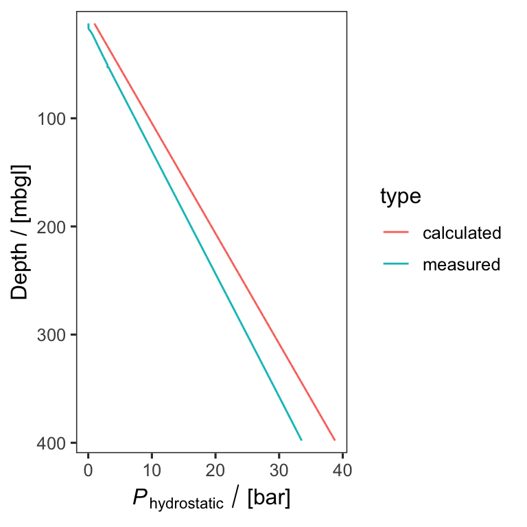

```r
plot_BA1D_2019_P <- BA1D_2019_profile_longer_P %>% ggplot(aes(x = depth_sampled_mbgl))+
  geom_line(aes(y = P_bar, color = type))+
  scale_x_reverse(name = "Depth / [mbgl]", expand = c(0.03,0.02))+
    scale_y_continuous(name = latex2exp::TeX("$\\textit{P}_{hydrostatic}\\,/\\,\\lbrack bar \\rbrack$"))+
  coord_flip()+
  theme_bw(base_size = 12)+
  theme(
    panel.grid = element_blank())

plot_BA1D_2019_P
```

## 5.4 Stability limits of water

Eh, f(T,P)

```r
Faraday <- 96485.33212331 # C/mol
R <- 8.31446261815324 # J/(mol⋅K) gas constant

BA1D_2019_profile <- BA1D_2019_profile %>% mutate(T_K= T_C + 273.15) # convert T to Kelvins

# calculate H20-H2 stability limit
BA1D_2019_profile <- BA1D_2019_profile %>% mutate(H2O_H2_limit_Eh_f_T_P_mV = (-R*T_K/2/Faraday * log(((10^-pH)^-2)*P_bar))*1000)

BA1D_2019_profile %>% select(H2O_H2_limit_Eh_f_T_P_mV) %>% summary()
```

```
##  H2O_H2_limit_Eh_f_T_P_mV
##  Min.   :-713.5
##  1st Qu.:-706.5
##  Median :-696.0
##  Mean   :-685.3
##  3rd Qu.:-683.6
##  Max.   :-401.9
```

```r
# prepare for plotting
BA1D_2019_profile_longer_Eh_T_P <- BA1D_2019_profile %>% select(depth_sampled_mbgl, Eh_mV, H2O_H2_limit_Eh_f_T_P_mV) %>% gather(-depth_sampled_mbgl, key = parameter, value = Eh_mV)
```

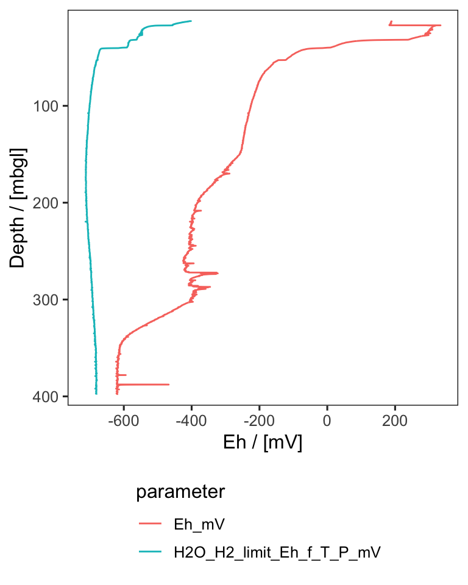

```r
plot_BA1D_2019_Eh <- BA1D_2019_profile_longer_Eh_T_P %>% ggplot(aes(x = depth_sampled_mbgl))+
  geom_line(aes(y = Eh_mV, color = parameter))+
  scale_x_reverse(name = "Depth / [mbgl]", expand = c(0.03,0.02))+
  scale_y_continuous(name = "Eh / [mV]")+
  coord_flip()+
  theme_bw(base_size = 12)+
  theme(
    panel.grid = element_blank(),
    legend.position = "bottom",
    legend.direction = "vertical")

plot_BA1D_2019_Eh
```

# 6 Prepare data for facet plot

Join well logs

```r
# join by type column
# also taking this opportunity to add some metadata for plotting, and also remove data above the casing depths, which may be spurious and obscure true trends in the boreholes
# BA1_profiles <- full_join((BA1A_2018_profile %>%mutate(sampling_site = "BA1A", year_sampled = 2018, group_id = "BA1A_2018_log") %>% filter(depth_sampled_mbgl > 22)), (BA1A_2017_profile %>% mutate(sampling_site = "BA1A", year_sampled = 2017, group_id = "BA1A_2017_log") %>% filter(depth_sampled_mbgl > 22))) %>% full_join((BA1D_2018_profile  %>% mutate(sampling_site = "BA1D", year_sampled = 2018, group_id = "BA1D_2018_log") %>% filter(depth_sampled_mbgl > 26))) %>% full_join((BA1D_2019_profile  %>% mutate(sampling_site = "BA1D", year_sampled = 2019, group_id = "BA1D_2019_log") %>% filter(depth_sampled_mbgl > 26))) %>% arrange(depth_sampled_mbgl)

BA1_profiles <- (BA1A_2018_profile %>% mutate(sampling_site = "BA1A", year_sampled = 2018, group_id = "BA1A_2018_log") %>% filter(depth_sampled_mbgl > 22)) %>% full_join((BA1D_2019_profile  %>% mutate(sampling_site = "BA1D", year_sampled = 2019, group_id = "BA1D_2019_log") %>% filter(depth_sampled_mbgl > 26))) %>% arrange(depth_sampled_mbgl)
# print first few lines
head(BA1_profiles)
```

| depth_sampled_mbgl | P_dbar | T_C | pH | ORP_mV_Ag_AgCl | cond_mS_per_cm | Eh_mV | water_column_above_m | P_hydrostatic_calc_Pa | P_hydrostatic_calc_bar | P_bar | T_K | H2O_H2_limit_Eh_f_T_P_mV | sampling_site | year_sampled | group_id |
| --- | --- | --- | --- | --- | --- | --- | --- | --- | --- | --- | --- | --- | --- | --- | --- |
| 22.0459 | 8.633637 | 34.18756 | 8.421251 | 46.17579 | 0.5581151 | 233.6456 | 12.95 | 222529.5 | 2.225295 | 0.8633637 | 307.3376 | -511.6022 | BA1A | 2018 | BA1A_2018_log |
| 22.0959 | 8.687404 | 34.18564 | 8.416876 | 46.44913 | 0.5577508 | 233.9210 | 13.00 | 223020.0 | 2.230200 | 0.8687404 | 307.3356 | -511.4144 | BA1A | 2018 | BA1A_2018_log |
| 22.1459 | 8.761820 | 34.18701 | 8.411590 | 46.36805 | 0.5578492 | 233.8384 | 13.05 | 223510.5 | 2.235105 | 0.8761820 | 307.3370 | -511.2073 | BA1A | 2018 | BA1A_2018_log |
| 22.1959 | 8.876269 | 34.18918 | 8.407838 | 46.30088 | 0.5578423 | 233.7690 | 13.10 | 224001.0 | 2.240010 | 0.8876269 | 307.3392 | -511.1540 | BA1A | 2018 | BA1A_2018_log |
| 22.2459 | 8.896483 | 34.19261 | 8.386694 | 46.74794 | 0.5576763 | 234.2125 | 13.15 | 224491.5 | 2.244915 | 0.8896483 | 307.3426 | -509.9004 | BA1A | 2018 | BA1A_2018_log |
| 22.2959 | 8.889586 | 34.19855 | 8.361169 | 47.18805 | 0.5571487 | 234.6464 | 13.20 | 224982.0 | 2.249820 | 0.8889586 | 307.3485 | -508.3433 | BA1A | 2018 | BA1A_2018_log |

## 6.1 Pivot longer for plotting on same scale

```r
BA1_profiles_longer <- BA1_profiles %>%
  select(sampling_site, year_sampled, depth_sampled_mbgl, pH, Eh_mV, group_id) %>%
  pivot_longer(cols = c(-sampling_site, -year_sampled, -depth_sampled_mbgl, -group_id), names_to = "parameter", values_to = "value", values_drop_na = TRUE)

BA1_profiles_longer %>% head()
```

| sampling_site | year_sampled | depth_sampled_mbgl | group_id | parameter | value |
| --- | --- | --- | --- | --- | --- |
| BA1A | 2018 | 22.0459 | BA1A_2018_log | pH | 8.421251 |
| BA1A | 2018 | 22.0459 | BA1A_2018_log | Eh_mV | 233.645602 |
| BA1A | 2018 | 22.0959 | BA1A_2018_log | pH | 8.416876 |
| BA1A | 2018 | 22.0959 | BA1A_2018_log | Eh_mV | 233.920951 |
| BA1A | 2018 | 22.1459 | BA1A_2018_log | pH | 8.411590 |
| BA1A | 2018 | 22.1459 | BA1A_2018_log | Eh_mV | 233.838438 |

## 6.2 Add packer sampling data

```r
# filter for data from only wells BA1A or BA1D
Oman_Geochem_BA1 <- Oman_Geochem %>%
 filter(sampling_site == "BA1A" | sampling_site == "BA1D") %>%
  # filter for 2019 only
  filter(year_sampled == 2019)

# print
Oman_Geochem_BA1
```

| sampling_site | year_sampled | month_sampled | day_sampled | depth_fluid_intake_mbct | notes | sampling_method | upper_packer_inflated | upper_packer_depth_mbct | lower_packer_inflated | lower_packer_depth_mbct | well_depth_mbgl | casing_extent_mbct | casing_height_magl | screened_interval_mbct | depth_to_water_mbct | first_publication_author | first_publication_year | first_publication_title | water_type | UTM_Easting_40N | UTM_Northing_40N | lat_deg_N_WGS84 | long_deg_E_WGS84 | elevation_masl | pH | temp_C | conductivity_uS_cm | Eh_mV | Na_total_uM | … |
| --- | --- | --- | --- | --- | --- | --- | --- | --- | --- | --- | --- | --- | --- | --- | --- | --- | --- | --- | --- | --- | --- | --- | --- | --- | --- | --- | --- | --- | --- | --- |
| BA1A | 2019 | 1 | 14 | 30 | NA | packer - Solexperts | FALSE | NA | TRUE | 30 | 400 | 22 | 1 | open below casing | 17.25 | NA | NA | NA | Mg_HCO3 | 674492 | 2531354 | 22.881 | 58.701 | 583 | 8.100 | 34.9 | 458 | 127.7 | 513.2666 | … |
| BA1A | 2019 | 1 | 16 | 65 | NA | packer - Solexperts | TRUE | 41 | TRUE | 65 | 400 | 22 | 1 | open below casing | 17.25 | NA | NA | NA | Mg_HCO3 | 674492 | 2531354 | 22.881 | 58.701 | 583 | 8.214 | 35.0 | 402 | 120.3 | 682.9056 | … |
| BA1A | 2019 | 1 | 16 | 132 | NA | packer - Solexperts | TRUE | 108 | TRUE | 132 | 400 | 22 | 1 | open below casing | 17.25 | NA | NA | NA | Ca_OH | 674492 | 2531354 | 22.881 | 58.701 | 583 | 10.670 | 36.5 | 871 | -248.6 | 3362.3314 | … |
| BA1D | 2019 | 1 | 11 | 75 | NA | packer - Solexperts | TRUE | 45 | TRUE | 75 | 400 | 26 | 1 | open below casing | 17.03 | NA | NA | NA | Ca_OH | 674492 | 2531354 | 22.881 | 58.701 | 584 | 10.862 | 34.6 | 1397 | -408.1 | 4032.1879 | … |
| BA1D | 2019 | 1 | 13 | 132 | NA | packer - Solexperts | TRUE | 102 | TRUE | 132 | 400 | 26 | 1 | open below casing | 17.03 | NA | NA | NA | Ca_OH | 674492 | 2531354 | 22.881 | 58.701 | 584 | 11.010 | 35.2 | 1716 | -412.4 | 5176.1635 | … |

```r
# Get the relevant data and pivot it longer
Oman_Geochem_BA1_select <- Oman_Geochem_BA1 %>%
  # get only relevant data
  select(sampling_site, year_sampled, upper_packer_depth_mbct, lower_packer_depth_mbct, well_depth_mbgl, casing_height_magl, pH, Eh_mV)

# add a group ID for plotting purposes
Oman_Geochem_BA1_select <- Oman_Geochem_BA1_select %>% mutate(group_id = paste0(sampling_site, "_", year_sampled, "_", if_else(is.na(upper_packer_depth_mbct), 0, upper_packer_depth_mbct), "-", if_else(is.na(lower_packer_depth_mbct), well_depth_mbgl, lower_packer_depth_mbct)))

  # pivot it longer
Oman_Geochem_BA1_longer  <-  Oman_Geochem_BA1_select %>%
  pivot_longer(cols = c(-sampling_site, -year_sampled, -upper_packer_depth_mbct, -lower_packer_depth_mbct, -well_depth_mbgl, -casing_height_magl, -group_id), names_to = "parameter", values_to = "value", values_drop_na = TRUE)

# convert/calculate sample depths
Oman_Geochem_BA1_longer <- Oman_Geochem_BA1_longer %>% mutate(upper_packer_depth_mbgl = if_else(!is.na(upper_packer_depth_mbct), upper_packer_depth_mbct + casing_height_magl, 0), lower_packer_depth_mbgl = if_else(!is.na(lower_packer_depth_mbct), lower_packer_depth_mbct + casing_height_magl, well_depth_mbgl))

# pivot longer depths for plotting as lines graphs
Oman_Geochem_BA1_longer_depth <- Oman_Geochem_BA1_longer %>%
  select(-upper_packer_depth_mbct, -lower_packer_depth_mbct, -well_depth_mbgl, -casing_height_magl) %>%
  pivot_longer(cols = c(-sampling_site, -year_sampled, -parameter, -value, -group_id), names_to = "depth_type", values_to = "depth_sampled_mbgl", values_drop_na = TRUE) %>%
  select(sampling_site, year_sampled, group_id, depth_sampled_mbgl, parameter, value)

Oman_Geochem_BA1_longer_depth
```

| sampling_site | year_sampled | group_id | depth_sampled_mbgl | parameter | value |
| --- | --- | --- | --- | --- | --- |
| BA1A | 2019 | BA1A_2019_0-30 | 0 | pH | 8.100 |
| BA1A | 2019 | BA1A_2019_0-30 | 31 | pH | 8.100 |
| BA1A | 2019 | BA1A_2019_0-30 | 0 | Eh_mV | 127.700 |
| BA1A | 2019 | BA1A_2019_0-30 | 31 | Eh_mV | 127.700 |
| BA1A | 2019 | BA1A_2019_41-65 | 42 | pH | 8.214 |
| BA1A | 2019 | BA1A_2019_41-65 | 66 | pH | 8.214 |
| BA1A | 2019 | BA1A_2019_41-65 | 42 | Eh_mV | 120.300 |
| BA1A | 2019 | BA1A_2019_41-65 | 66 | Eh_mV | 120.300 |
| BA1A | 2019 | BA1A_2019_108-132 | 109 | pH | 10.670 |
| BA1A | 2019 | BA1A_2019_108-132 | 133 | pH | 10.670 |

[output cut: 10 more lines]

```r
BA1_profiles_and_packer_geochem <- full_join((BA1_profiles_longer %>% mutate(sample_method = "Wireline logging")), (Oman_Geochem_BA1_longer_depth %>% mutate(sample_method = "Packer")))
```

Prepping data to plot and label correctly

```r
# set factors to set order of parameters on plot
BA1_profiles_and_packer_geochem$parameter <- factor(BA1_profiles_and_packer_geochem$parameter, levels = c("pH", "Eh_mV"))

# rename how parameters should be displayed on plot using LaTeX
BA1_profiles_and_packer_geochem <- BA1_profiles_and_packer_geochem %>%
  mutate(
    tex_params = as_factor(parameter) %>%
      fct_recode(
        # "T / $\\lbrack$$\\degree$C$\\rbrack$" = "T_C",
        "pH" = "pH",
        "$\\textit{Eh}$ / $\\lbrack$mV$\\rbrack$" = "Eh_mV"
  )
  )
```

## 6.3 Plot

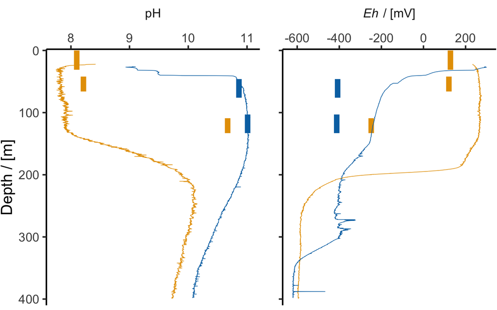

```r
BA1_profiles_plot <- BA1_profiles_and_packer_geochem %>% ggplot(aes(
  x = depth_sampled_mbgl,
  # linetype = as.character(year_sampled),
  color = sampling_site,
  # linetype = sample_method,
  size = sample_method,
  group = group_id
  )) +

  # add line graph for applicable parameters
  geom_line(data = (BA1_profiles_and_packer_geochem %>% filter(parameter == "pH" | parameter == "Eh_mV")), aes(y = value)) +

  # flip coordinates (this makes it possible to do vertical line graph)
    coord_flip() +

  # plot styling
  scale_color_manual(name = "Well", values = c("BA1A" = "#E69F00", "BA1D" = "#0072B2"))+
  scale_size_manual(name = "Method", values = c("Wireline logging" = 0.3, "Packer" = 3)) +
  scale_x_reverse(name = "Depth / [m]", limits = c(410, -2), expand = c(0, 0)) +
  scale_y_continuous(name = NULL, sec.axis = dup_axis()) +

  # generate plot facets
  facet_rep_grid(cols = vars(tex_params), scales = "free", labeller = latex_labeller)+

    # plot design
  theme_classic(base_size = 18) +
  theme(
    legend.position = "none",
    # legend.direction = "vertical",
    panel.grid = element_blank(),
    plot.margin = margin(1,1,1,1),
    strip.placement = "outside",
    axis.text.x.bottom = element_blank(),
    axis.ticks.x.bottom = element_blank(),
    axis.line.x.bottom = element_blank(),
    axis.line.y.left = element_line(),
    strip.background = element_blank(),
    strip.text.y = element_blank(),
    panel.spacing = unit(-5, "pt")
  )


BA1_profiles_plot
```